# 人工智慧 進階課程 - Deep Learning- 課程 21 - Deep Learning- Capsule Networks Part- 02 - An introduction to Capsule Network Workflow - Python Tutorial

''' 人工智慧- 進階課程 A.I Tutorials - 進階課程 Advanced Course - Deep Learning 教程 ''' 05 - 深度學習 教程 課程 21 - Deep Learning- Capsule Networks Part- 02 - An introduction to Capsule Network Workflow 程式範例 - Cifar -10 數據集 - CNN / Capsule Network ''' ''' >> 資料準備 >> 你我互動學習園地- 進階課程 Advanced Course >> https://interactiveuandmetutorialsac.weebly.com/ >> 你我互動學習園地 >> https://interactiveuandmetutorials.weebly.com/ >> Python 程式語言 設計 >> https://pythonprogrammingtutorials.weebly.com/ >> 課程 21 - 目錄結構 課程 21 - Deep Learning- Capsule Networks Part- 02 ├ ├── datasets/ ├ ├── cifar.py ├ ├── fashion_mnist.py ├ ├── mnist.py ├ ├── utils.py ├ └── visualization.ipynb ├── images ├ ├── capsule_archi.png ├ ├── mnist_CNN_history.png ├ ├── mnist_CNN_history_light.png ├ ├── mnist_history.PNG ├ ├── mnist_history_light.png ├ └── training_archi.png ├ ├── keras_capsnet ├ ├── layer ├ ├ └── capsnet.py ├ ├── activations.py ├ └── losses.py ├ ├── keras_lropt ├ └── callbacks.py ├ ├── NoUI ├ ├── cifar_NoUI.py ├ └── mnist.py ├ └── utils.py '''

''' - 深度學習 之父 - Geoffrey Hinton - Deep Learning 深度學習的 - 創始人之一 - 眾多模型 和 算法 Algorithms 的 發明者 '''

[figure not shown]

```python
- Hinton 和 他的 團隊

    - 發表 兩篇論文
        - Published Two Paper
    - 膠囊 Capsules
        - 新型的 神經網絡
        - new type of Neural Network

    - 膠囊之間的 動態路由
        - Dynamic Routing Between Capsules
            - https://arxiv.org/abs/1710.09829

    - EM 佈線 矩陣膠囊
        - MATRIX CAPSULES WITH EM ROUTING
        - https://openreview.net/pdf?id=HJWLfGWRb
```

''' - Capsule Networks - 膠囊 Capsules 引入了一個 新的 構建基塊 New Building Block - 可用於 深度學習中 - 以更好地建模神經網絡 - 內部的 層次關係 Hierarchical Relationships - 提出了一種訓練 - 一個簡單的 數據集 - 訓練 - 由膠囊 Capsules 組成的 - 網絡 Capsules Network - CapsNets 的方法 - 並成功地 - 在這一個簡單的數據集上 - 進行了訓練 - 錯誤率 Error Rate 降低了 45％ - 非常令人鼓舞的 - 儘管如此 當前的 結果比其他現代深度學習模型要 - 慢得多 slower - 時間 Time - 膠囊網絡 capsule networks 是否可以 更快速 及有效地訓練 - 此外 - 需要查看它們是否適用 - 於更多 更困難的數據集 以及 不同領域 - Difficult Data Sets and in Different Domains '''

[figure not shown]

- 什麼是膠囊 Capsule - 膠囊 Capsule - 指 神經元 的 集合 - 其活動 向量 - 代表 視野 Visual Field - 或 對像 或 對象部分的實例參數 - The term capsule - refers to a collection of neurons whose activity vector - represents the visual field - or the instance parameters of the object or the object part.

''' - 膠囊 Capsule - 如何在內部 起作用 - How it Works Internally '''''' - How does a capsule work? - 什麼是膠囊 Capsule ? - 膠囊 Capsule - 的 第一篇 論文 - Capsules that First Paper >> Transforming Autoencoders - http://www.cs.toronto.edu/~fritz/absps/transauto6.pdf '''''' - 人工神經網絡 - 應該 使用局部 - 膠囊 Capsules - 而不是針對使用 - 單個標量輸出 Single Scalar Output - 膠囊 Capsules - 表示 局部特徵檢測器 - 運作 Activities Of " 神經元 Neurons " 的運作 - 視點不變性 Viewpoint Invariance - 而應使用 - 膠囊 Capsules - 的輸入 - 然後 - 將這些計算的結果 - 封裝 Encapsulate 到一個高度信息量小的 - Small Vector Of Highly Informative Outputs - 輸出向量中 Victor outputs - 每個膠囊 capsules - 學會在 有限域中 Limited Domain - 觀看條件 和 變形的 - Viewing Conditions and Deformations - 識別 實體 - 並輸出該實體 - 存在於 有限域中 - 一組 概率和一組 -實例化參數 Instantiation parameters - 其中 可能 - 包括 - 精確的姿勢 Pose - 照明視覺實體 Lighting - 相對於 - 實體 隱式定義 - 該實體 變形 和 變形 - Deformation of the visual entity relative - 當膠囊 正常工作時 - 視覺實體存在的 概率是 - 局部不變的 -當實體在膠囊 - 所覆蓋的有限域內的可能出現的流形上移動時 - 它不會改變 -但是 - 實例化參數是 等變的 Equivariant - 當觀看條件發生變化 - 並且實體在外觀流形上移動時， - 實例化參數 - 會改變相應的量 - 因為 - 表示實體在 外觀流形上的內在坐標 - Instead of aiming for viewpoint invariance in the activities of “neurons” - that use a single scalar output - to summarize the activities of a local pool - of replicated feature detectors - artificial neural networks should use local “capsules” - that perform some quite complicated internal computations on their inputs - and then encapsulate the results of these computations - into a small vector of highly informative outputs - Each capsule learns to recognize an implicitly - defined visual entity over a limited domain of viewing conditions - and deformations and it outputs both the probability - that the entity is present within - its limited domain and a set of “instantiation parameters” - that may include - the precise pose, lighting and deformation - of the visual entity relative to an - implicitly defined canonical version of that entity. - When the capsule is working properly - the probability of the visual entity being present is locally invariant - it does not change as the entity moves over the manifold - of possible appearances within the limited domain - covered by the capsule. The instantiation parameters - however - are “equivariant” — as the viewing conditions change - and the entity moves over the appearance manifold, - the instantiation parameters change by a corresponding amount - because they are representing - the intrinsic coordinates of the entity on the appearance manifold. ” '''

''' - 人工神經元輸出 Neurons Output 單個標量 - Single Scalar - CNN 使用卷積層 Convolutional Layers - 對於每個內核 - Each Kernel - 該卷積層 - 將同一內核的權重 - Kernel’s Weights - 複製到整個輸入 Entire Input Volume - 然後 輸出一個2D矩陣 - 2D matrix - 其中每個數字 - 是該內核卷積與一部分輸入體積的輸出 - Kernel’s Convolution with a portion of the input volume - 因此 - 可以將 2D矩陣 2D matrix - 視為複制特徵檢測器的輸出 - 然後 - 所有內核的2D矩陣 - 彼此堆疊 stacked 以產生卷積層的輸出 - Output Of a Convolutional Layer '''''' >> 卷積神經網絡 - Convolutional Neural Networks - LeNet '''

[figure not shown]

''' >> 膠囊 神經網絡 - Capsule Networks '''

[figure not shown]

''' - 人工神經元輸出 Neurons Output 單個標量 - Single Scalar - CNN 使用卷積層 Convolutional Layers - 對於每個內核 - Each Kernel - 該卷積層 - 將同一內核的權重 - Kernel’s Weights - 複製到整個輸入 Entire Input Volume - 然後 輸出一個 2D 矩陣 - 2D matrix - 其中每個數字 - 是該內核卷積與一部分輸入體積的輸出 - Kernel’s Convolution with a portion of the input volume - 因此 - 可以將 2D矩陣 2D matrix - 視為 複制特徵檢測器的 輸出 - 然後 - 所有內核的 2D 矩陣 - 彼此堆疊 stacked 以產生卷積層的輸出 - Output Of a Convolutional Layer '''

[figure not shown]

''' - CapsNet不僅可以識別數字，還可以從內部表示形式生成數字 - Dynamic Routing Between Capsules - https://arxiv.org/pdf/1710.09829.pdf '''''' - 嘗試實現 神經元活動中 Activities of Neurons - 的 視點不變性 Viewpoint Invariance - 通過 Means of Max Pooling 的方法 - 來做到這一點 - 該 Pooling 連續查看 上述 2D 矩陣中的 區域 - 並選擇 每個區域中的 最大數目 - Selects the Largest Number in each egion - 結果 - 得到了我們 想要的 -活動的不變性 Invariance of Activities - 不變性意味著 - 通過稍微改變輸入 - 輸出仍然 保持不變 - Input a little - The output still stays the same - 只是神經元的輸出信號 - 換句話說 - 當我們在 輸入圖像中稍微移動 要檢測的對象時 - 由於 Max Pooling，網絡活動（神經元的輸出）將不會改變 - 並且網絡 仍會檢測到對象 - 上面描述的機制不是很好 - 因為最 Max Pooling - 會丟失有價值的信息 - Max Pooling Loses Valuable Information - 並且也不會對要素之間的相對空間關係進行編碼 - Does Not Encode Relative Spatial Relationships between Features - 改用膠囊 Capsules - 因為 將以向量的形式 Form Of A Vector - 與神經元輸出的標量 Scalar 相對比較 - 封裝所有有關所檢測特徵狀態 State Of The Features 的重要信息 - Encapsulate All Important Information '''''' - 膠囊 Capsules - 以向量形式 封裝了 - 有關它們正在 檢測的 特徵狀態 的 所有重要信息 - Capsules - Vector form - encapsulate all important information - about the state of the feature they are detecting in vector form '''''' - 膠囊 Capsules - 將 特徵檢測的概率 編碼 - Encode Probability of Detection of a Feature - 為其 輸出向量 的長度 - Length Of Their Output Vector - 並且將檢測到的 特徵的狀態 編碼為向量 Vector form - 指向的方向（“實例化參數 Instantiation Parameters”） -因此 - 當檢測到的特徵 - 在圖像周圍移動或狀態發生某種變化時 - When Detected Feature Moves Around The Image or - Its State Somehow Changes - the probability still stays the same - (length of vector does not change) - but its orientation changes. - 概率 仍然保持不變(向量的長度不變) - Probability Still Stays The Same - (Length Of Vector Does Not Change), - 但是其方向發生了變化- 改變改 - But Its Orientation Changes. '''

[figure not shown]

''' - 使用CNN - 繪製鼻子，嘴巴，眼睛 的 位置 - 可以使用 CapsNet - 固定確切的對齊方式 Alignment或 3D 結構 3D Structure '''

[figure not shown]

''' - 想像一下 - 膠囊 Capsule 檢測到圖像中的人臉 Face Imagine - 並輸出長度 為 0.99 的 3D 向量 Vector - 然後 - 開始在 圖像上移動人臉 - 向量 Vector 將 空間中 旋轉 otate - 代表 檢測到的臉部的 變化狀態 - 但是其 長度 將保持固定 - 因為 膠囊 Capsule － 仍確定已檢測到臉部 - 這就是 - 欣頓 Hinton - 所說的活動等方差 Ectivities Equivariance - 當物體 - 移動到可能出現的圖像中 時 - moves over the manifold of possible appearances - 神經元活動將發生變化 - 同時，檢測的概率保持不變 - Probabilities of Detection Remain Constant - 這是我們應針對的不變性形式 - Invariance - 而不是 CNN 提供的 類型 - 具有最大合併量的 - Max Pooling - CapsNet - 膠囊 CapsNet 試圖通過 - 方差 Equivariance來解決 Max Pooling 的問題 - 這表明 - 膠囊 CapsNet - 使視點相等 Viewpoint-Equivariant - 而不是使函數平移 Function Translation In Variance - 因此，當函數前進並改變其在圖片中的位置時 - 函數向量 Function Vector Reflection 反射 - 也將以使其 - 等變 Equivariant 的相同方式 發生變化 '''

''' - 膠囊 Capsule 如何工作 - 膠囊 和 神經元之間 的重要區別 - Differences Between Capsules And Neurons - https://github.com/naturomics/CapsNet-Tensorflow '''

[figure not shown]

''' - 神經元 Neuron - 從其他神經元接收輸入標量 Scalars - 然後 將它們 Multiplies X 乘以標量權重 Scalar Weights 和 總和 Sums - 然後 將該總和傳遞到許多可能的非線性激活 Nonlinear Activation 函數之一 - 該函數 採用輸入標量 Input scalar - 並根據 該函數 輸出標量 Output Scalar - 標量 Scalars 將是神經元的輸出 - 將作為其他神經元的輸入 - 該過程的摘要可以在右側的下表和圖表中看到 - 人工神經元 可以通過 3個步驟 描述： 1. 輸入標量的 加權 - Scalar Weighting Of Input Scalars 2. 加權輸入標量的 之和 - Sum Of Weighted Input Scalars 3. 標量到標量的 非線性 - Scalar To Scalar Nonlinearity '''

[figure not shown]

```python
- 左圖：膠囊圖 Capsule Diagram；    右圖 ：人工神經元  Artificial Neuron
```

''' - 膠囊 Capsule - 除了新步驟（輸入的仿射變換 Affine Transform Of Input）之外 - 膠囊還具有上述3個步驟的向量形式 Vectors Form： 1. 輸入向量的矩陣乘法 - Matrix Multiplication Of Input Vectors 2. 輸入向量的標量加權 - Scalar Weighting Of Input Vectors 3. 加權輸入向量之和 - Sum Of Weighted Input Vectors 4. 向量對向量非線性 - Vector To Vector Nonlinearity '''

[figure not shown]

''' 1. 輸入向量的矩陣乘法 - Matrix Multiplication Of Input Vectors '''''' - Neuron 的輸出是一個 Value / Scalars - Capsule 的輸出是一個 Vector '''''' - 膠囊 接收的輸入向量（圖中的u1，u2和u3） - 來自下一層中的 - 其他3個膠囊 - 這些向量的長度編碼 - 較低級別的膠囊檢測到其相應對象的概率 - 並且向量的方向編碼檢測到的對象的 - 某些內部狀態 - 假設較低水平的膠囊 - 分別檢測眼睛，嘴巴和鼻子 - 而外面的膠囊則檢測面部 - 然後 - 將這些向量乘以相應的權重矩陣 W - 該權重矩陣W編碼較低層特徵（眼睛，嘴巴和鼻子） - 和較高層特徵（面部）之間的重要空間關係和其他關係 例如 - 矩陣 W2j 可以編碼鼻子和臉部之間的關係 - 臉部以鼻子為中心，其大小是鼻子的10倍 - 並且其空間方向與鼻子的方向相對應，因為它們都位於同一平面上 - 可以為 矩陣 W1j 和 W3j 得出類似的直覺 - 與這些矩陣相乘後 - 得到的是更高層特徵的預測位置 - 換句話說，u^1 代表 - u^1 表示 檢測到的 臉 應根據 眼睛位置 面部 應該處於的位置 - u^2 表示 檢測到的 臉 應根據 口 和的檢測位置 - u^3 表示 檢測到的 臉 應根據 鼻子 和的檢測位置 - 此時，您的直覺應該如下 - 這3個較低級別特徵的預測 - 指向 - 同一張面孔 - 同一張面孔的狀態 - 那一定是一張面孔 '''

[figure not shown]

```python
- 鼻子，嘴巴 和眼睛 的膠囊的面部位置預 測緊密 匹配
```

''' - 一個神經元 負責檢測特定的模式（Specific Pattern） - 如 - Neuron A 負責檢測向左 的鳥嘴 - Neuron B 負責檢測向右 的鳥嘴 -Capsule 負責檢測某一個種類的 pattern - 輸出 V 的長度代表某一 Pattern 是否存在 - 再用其中的某一些細節 - 來表示是哪一種類的 pattern - 如：是否有鳥嘴 - 以及 該鳥嘴 - 是向左的 - 是向右的 '''

[figure not shown]

''' - Capsule 輸出的向量，長度都是 1 - 但是 - 1.0 來表示向左 的鳥嘴 - 1.0 來表示向右 的鳥嘴 '''

''' 2. 輸入向量的標量加權 - Scalar Weighting Of Input Vectors ''' ''' - 人工神經元 - 在將其輸入相加之前 先對其輸入進行加權 X Weight - 在神經元 N euron的情況下 - 這些權重是在反向傳播 BackproPagation過程中學習的 - 在膠囊 Capsule的情況下 - 是使用 - 動態路由 Dynamic Routing - 確定的 - 一種確定每個膠囊輸出的去向 '''

[figure not shown]

```python
- 上圖中
- 較低級別的容器 Lower Level Capsule
    - 會將其輸入 發送到  - 同意 agree - 其輸入的較高級別 Higher Level Capsule 的容器
```

''' - 上圖中，有一個較低級別的容器 - 需要 決定 將其輸出發送到哪個較高級別的容器 - 將通過 調整權重 C 做出決定 - 該權重 C 將在將此膠囊的輸出 - 發送到 左 或 右 較高級別的 膠囊 J 和 K 之前將其乘以 - 現在 - 較高級別的容器 - 已經 從其他 較低級別的容器 接收了許多 輸入向量 - 所有這些輸入均由紅色和藍色點表示 - 當這些點聚集在一起時 - 這意味著較低水平的膠囊的預測彼此接近 - 這就是為什麼 - 例如，膠囊J和K中都有一簇紅點 - 那麼 - 下層膠囊應該將其輸出發送到哪裡 - 膠囊 J 或 膠囊 K？ - 答案是動態路由算法的本質 - 當下層膠囊的輸出 乘以相應的 矩陣 W時 - 其 落差 與膠囊 J中 - 正確 - 預測的 紅色簇 相距甚遠 - 另一方面 - 它落在非常接近右側膠囊中的 - 真實 -預測紅色簇 - K.下層膠囊 具有 測量哪個上層膠囊 - 更好地適應其結果的機制，並會自動調節其重量 - 以使 與 - 膠囊 K相對應的重量 C 高 - 而 與 膠囊 J相對應的重量 C 低 '''

''' 3. 加權輸入向量之和 - Sum Of Weighted Input Vectors - 代表輸入的組合 - 向量之和 - Sum Of Vectors - 而不是標量之和 - Not Sum Of Scalars ''' ''' 4. 向量 對向量非線性 - Squash - Vector To Vector Nonlinearity - CapsNet 是採用向量 新的 非線性激活函數 - 然後將其 - 壓扁 Squash ，使其長度不超過1，但不會改變其方向 '''

[figure not shown]

- 上圖中 - 壓縮 Squashing 非線性 可縮放 輸入向量 - 而無需更改其方向 - 等式的右側（藍色矩形）縮放 輸入向量 - 使其具有單位長度 - 等式的左側（紅色矩形）執行附加縮放 Squashing - 輸出向量長度 - 可以解釋為膠囊 Capsule 檢測 到 特徵 Feature的概率 probability

# Mnist 手寫體識別 數據集上

- Capsule 可以替換掉 Filter - 以 Mnist 手寫體識別 - 可以用一個 Capsule 來表示一類數字， - 10個 數字 - 需要 10 個 Capsule 來表達 - 假設輸入的圖像是 1 - 對應 1 的vector 置信度 - 就盡可能的高

[figure not shown]

# 膠囊網絡(CapsNets)

```python
from IPython.display import HTML
HTML("""<iframe width="560" height="315" src="https://www.youtube.com/embed/pPN8d0E3900" frameborder="0" allowfullscreen></iframe>""")
```

[video not shown]

# CNN - Cifar - 10

```python
import platform
```

```python
!python -V
platform.python_version()
```

```
Python 3.7.3
```

```
'3.7.3'
```

```python
import keras
keras.__version__
```

```
'2.2.4'
```

```python
import tensorflow
import keras
print("Platform: {}".format(platform.platform()))
print("Tensorflow version: {}".format(tensorflow.__version__))
print("Keras version: {}".format(keras.__version__))
```

```
Platform: Windows-10-10.0.18362-SP0
Tensorflow version: 1.14.0
Keras version: 2.2.4
```

''' - STEP 1 - Import 載入相關 函式庫 - Import the required libraries '''

```python
import numpy as np
import seaborn as sns
from keras.models import Sequential
from keras.layers.convolutional import Convolution2D, MaxPooling2D
from keras.layers.core import Dense, Reshape, Activation, Flatten
from keras.layers import Input, BatchNormalization, Dropout
from keras.losses import categorical_crossentropy
from keras.optimizers import Adam, SGD
from keras.utils import plot_model, multi_gpu_model

from utils import LossHistory, plotHistory, visualization_data, rotation_accuracy
from datasets.cifar import dataGenerator
from keras_lropt.callbacks import LRFinderAuto as LRFinder
```

```python
# Plotting for dark theme
sns.set(context='paper', style='darkgrid', rc={'figure.facecolor':'white'}, font_scale=1.2)
```

# Parameters

```python
num_class = 10
input_shape = (32, 32, 3)

m_train = 60000
m_test  = 10000

batch_size = 32

data_augmentation = {
    'width_shift_range': 2,
    'height_shift_range': 2
}

test_augmentation = {
    'width_shift_range': 10,
    'height_shift_range': 10
}
```

# Dataset

```python
trainGenerator = dataGenerator('train', batch_size=batch_size, reshape=False, **data_augmentation)
testGenerator = dataGenerator('test', batch_size=batch_size, reshape=False)
```

# Model

```python
model = Sequential([
    Convolution2D(filters=128, kernel_size=(5, 5), padding='same', input_shape=input_shape),
    MaxPooling2D(),
    BatchNormalization(),
    Activation('relu'),
    Dropout(0.2),

    Convolution2D(filters=256, kernel_size=(3, 3), padding='same'),
    MaxPooling2D(),
    BatchNormalization(),
    Activation('relu'),
    Dropout(0.2),

    Flatten(),
    Dropout(0.2),
    Dense(10, activation='softmax')
])
plot_model(model, show_shapes=True)
```

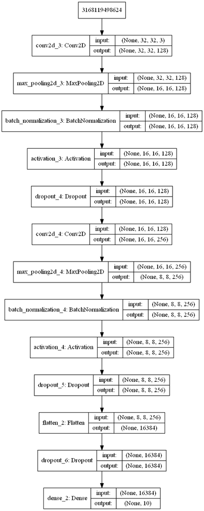

```python
# Plot model graph
plot_model(model, show_shapes=True, show_layer_names=True, to_file='Cifar_CNNmodel.png')
from IPython.display import Image
Image(retina=True, filename='Cifar_CNNmodel.png')
```

```python
model.summary()
```

```
_________________________________________________________________
Layer (type)                 Output Shape              Param #
=================================================================
conv2d_3 (Conv2D)            (None, 32, 32, 128)       9728
_________________________________________________________________
max_pooling2d_3 (MaxPooling2 (None, 16, 16, 128)       0
_________________________________________________________________
batch_normalization_3 (Batch (None, 16, 16, 128)       512
_________________________________________________________________
activation_3 (Activation)    (None, 16, 16, 128)       0
_________________________________________________________________
dropout_4 (Dropout)          (None, 16, 16, 128)       0
_________________________________________________________________
conv2d_4 (Conv2D)            (None, 16, 16, 256)       295168
_________________________________________________________________
max_pooling2d_4 (MaxPooling2 (None, 8, 8, 256)         0
_________________________________________________________________
batch_normalization_4 (Batch (None, 8, 8, 256)         1024
_________________________________________________________________
activation_4 (Activation)    (None, 8, 8, 256)         0
_________________________________________________________________
dropout_5 (Dropout)          (None, 8, 8, 256)         0
_________________________________________________________________
flatten_2 (Flatten)          (None, 16384)             0
_________________________________________________________________
dropout_6 (Dropout)          (None, 16384)             0
_________________________________________________________________
dense_2 (Dense)              (None, 10)                163850
=================================================================
Total params: 470,282
Trainable params: 469,514
Non-trainable params: 768
_________________________________________________________________
```

# Training

```python
model.compile(optimizer=Adam(lr=1e-4), loss=categorical_crossentropy, metrics=['accuracy'])
```

```
W1212 15:48:27.478244 134216 deprecation_wrapper.py:119] From C:\Users\calvi\Anaconda3\lib\site-packages\keras\optimizers.py:790: The name tf.train.Optimizer is deprecated. Please use tf.compat.v1.train.Optimizer instead.
```

```python
history = LossHistory(metrics=('loss', 'acc'))
```

```python
%%time
hist = model.fit_generator(trainGenerator,
                                    steps_per_epoch=50000 // batch_size,
                                    epochs= 10,
                                    validation_data=testGenerator,
                                    validation_steps=10000 // batch_size,
                                    verbose=1,
                                    callbacks=[history])
```

```
W1212 15:48:44.580678 134216 deprecation.py:323] From C:\Users\calvi\Anaconda3\lib\site-packages\tensorflow\python\ops\math_grad.py:1250: add_dispatch_support.<locals>.wrapper (from tensorflow.python.ops.array_ops) is deprecated and will be removed in a future version.
Instructions for updating:
Use tf.where in 2.0, which has the same broadcast rule as np.where
```

```
Wall time: 56min 41s
```

```python
model.save('Cifar_CNNmodel.h5')  # creates a HDF5 file 'my_model.h5'
```

```python
hist.history['loss']
```

```
[1.6217748436518729,
 1.2115921999375254,
 1.0585300915141231,
 0.9643220656428855,
 0.8928140540784114,
 0.8420079954343082,
 0.7990892115900465,
 0.7609932122229003,
 0.7249730170212073,
 0.692351463720503]
```

```python
hist.history['acc']
```

```
[0.44662291933418696,
 0.5828530259365994,
 0.6350064040986231,
 0.6686679474863912,
 0.691482548831252,
 0.7109750240153698,
 0.722942683317323,
 0.7352505603586296,
 0.7490193723983349,
 0.7603466218379763]
```

```python
hist.history['val_loss']
```

```
[1.2584114072796626,
 1.071071326158594,
 0.9502810982218907,
 0.9537826575589984,
 0.9392983124114537,
 0.804252516687586,
 1.044744526689355,
 0.9351811127716236,
 0.862099643025314,
 0.8701063347666451]
```

```python
hist.history['val_acc']
```

```
[0.5602964743589743,
 0.6255016051364366,
 0.6673354735152488,
 0.6731540930979133,
 0.6724518459069021,
 0.7287319422150883,
 0.648876404494382,
 0.6853932584269663,
 0.701645264847512,
 0.7045545746388443]
```

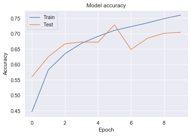

[figure not shown]

```python
import matplotlib.pyplot as plt

# Plot training & validation accuracy values

fig=plt.figure()
plt.plot(hist.history['acc'])
plt.plot(hist.history['val_acc'])

plt.title('Model accuracy')
plt.ylabel('Accuracy')
plt.xlabel('Epoch')
plt.legend(['Train', 'Test'], loc='upper left')
plt.show()

fig.savefig('Cifar_CNNmodel1.png')


# Plot training & validation loss values
fig=plt.figure()
plt.plot(hist.history['loss'])
plt.plot(hist.history['val_loss'])
plt.title('Model accuracy')
plt.ylabel('Accuracy')
plt.xlabel('Epoch')
plt.legend(['Train', 'Test'], loc='upper left')
plt.show()

fig.savefig('Cifar_CNNmodel2.png')
```

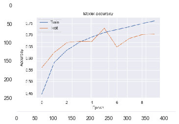

```python
import matplotlib.image as img
im1 =img.imread('Cifar_CNNmodel1.png')
plt.imshow(im1)
```

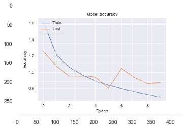

```python
import matplotlib.image as img
im2 =img.imread('Cifar_CNNmodel2.png')
plt.imshow(im2)
```

[figure not shown]

```python
plotHistory(hist.history)
```

plotHistory(hist.metrics)

# Evaluation on augmented data

## Accuracy

Test accuracy for different rotations on test data

```python
rotation_accuracy(model, dataGenerator, n_points=10, batch_size=batch_size)
```

```
Test acc [0.0°]:	0.703
Test acc [20.0°]:	0.654
Test acc [40.0°]:	0.554
Test acc [60.0°]:	0.47
Test acc [80.0°]:	0.42
Test acc [100.0°]:	0.385
Test acc [120.0°]:	0.351
Test acc [140.0°]:	0.338
Test acc [160.0°]:	0.32
Test acc [180.0°]:	0.313
```

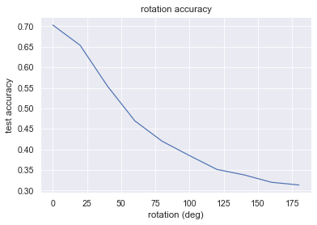

```python
rotation_accuracy(model, dataGenerator, m_test=m_test, batch_size=batch_size)
```

```python
rotation_accuracy(model, dataGenerator, n_points=10, batch_size=batch_size)
```

## Visualization

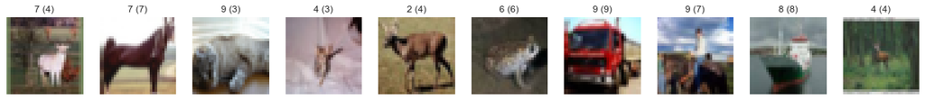

```python
n_image= 10

# Select data
testGenerator = dataGenerator('test', batch_size=n_image, reshape=False, **data_augmentation)
images, labels = next(testGenerator)

# Run inference
predictions = model.predict(images)

# Post-process data
labels = np.argmax(labels, axis=1)
predictions = np.argmax(predictions, axis=1)

visualization_data(images, labels, predictions)
```

# Capusle - Cifar-10

```python
import numpy as np
import seaborn as sns
from matplotlib import pyplot as plt
from keras.models import Model, Sequential
from keras.layers.convolutional import Convolution2D
from keras.layers.core import Dense, Reshape, Dropout, Activation
from keras.layers import Input, BatchNormalization, GlobalAveragePooling2D
from keras.losses import mean_squared_error, categorical_crossentropy
from keras.optimizers import Adam
from keras.utils import plot_model, multi_gpu_model

from utils import LossHistory, plotHistory, visualization_train, visualization_data, rotation_accuracy
from keras_capsnet.layer.capsnet import PrimaryCaps, Caps, ClassesCaps, Mask, CapsCNN
from keras_capsnet.losses import margin
from keras_capsnet.activations import squash
from datasets.cifar import dataGenerator
from keras_lropt.callbacks import LRFinderAuto as LRFinder
```

```python
# Plotting for dark theme
sns.set(context='paper', style='darkgrid', rc={'figure.facecolor':'white'}, font_scale=1.2)
```

# Parameters

```python
num_class = 10
input_shape = (32, 32, 3)

m_train = 50000
m_test  = 10000

batch_size = 16

data_augmentation = {
    'width_shift_range': 2,
    'height_shift_range': 2
}

test_augmentation = {
    'width_shift_range': 10,
    'height_shift_range': 10
}
```

# Dataset

```python
trainGenerator = dataGenerator('train', batch_size=batch_size, reshape=False, **data_augmentation)
testGenerator = dataGenerator('test', batch_size=batch_size, reshape=False)
```

# Model

```python
model = Sequential([
    Convolution2D(filters=128, kernel_size=(9, 9), padding='valid', activation='relu', input_shape=input_shape),
    Convolution2D(filters=128, kernel_size=(9, 9), strides=2, padding='valid', activation='relu'),

    CapsCNN(64, kernel_size=(5, 5), routings=3, activation_caps=squash),

    GlobalAveragePooling2D(),
    Dense(10, name='capsule')
])
plot_model(model, show_shapes=True)
```

```
W1212 16:50:31.094342 134216 deprecation.py:506] From C:\Users\calvi\OneDrive\桌面\Capsulerecord\CapsNet-for-Keras-master\CapsNet-for-Keras-master\keras_capsnet\layer\capsnet.py:125: calling extract_image_patches (from tensorflow.python.ops.array_ops) with ksizes is deprecated and will be removed in a…
Instructions for updating:
ksizes is deprecated, use sizes instead
```

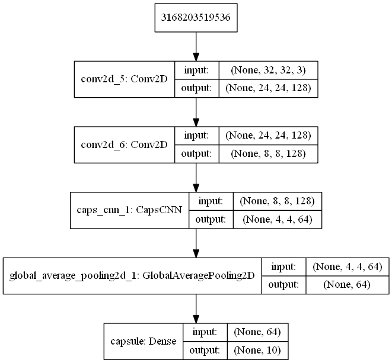

```python
# Plot model graph
plot_model(model, show_shapes=True, show_layer_names=True, to_file='CapsuleCifarmodel.png')
from IPython.display import Image
Image(retina=True, filename='CapsuleCifarmodel.png')
```

```python
model.summary()
```

```
_________________________________________________________________
Layer (type)                 Output Shape              Param #
=================================================================
conv2d_5 (Conv2D)            (None, 24, 24, 128)       31232
_________________________________________________________________
conv2d_6 (Conv2D)            (None, 8, 8, 128)         1327232
_________________________________________________________________
caps_cnn_1 (CapsCNN)         (None, 4, 4, 64)          204800
_________________________________________________________________
global_average_pooling2d_1 ( (None, 64)                0
_________________________________________________________________
capsule (Dense)              (None, 10)                650
=================================================================
Total params: 1,563,914
Trainable params: 1,563,914
Non-trainable params: 0
_________________________________________________________________
```

# Training

```python
model.compile(optimizer=Adam(lr=3e-4),
              loss=margin(),
              metrics={'capsule': 'categorical_accuracy'})
```

```python
%%time
hist = model.fit_generator(trainGenerator,
                           steps_per_epoch=trainGenerator.n // trainGenerator.batch_size,
                           epochs= 10,
                           validation_data=testGenerator,
                           validation_steps=testGenerator.n // testGenerator.batch_size,
                           workers=4,
                           verbose=1)
```

```
Wall time: 1h 9min 13s
```

```python
model.save('CapsuleCifarmodel.h5')  # creates a HDF5 file 'my_model.h5'
```

```python
hist.history['loss']
```

```
[0.42624207689285276,
 0.3685031089544296,
 0.34298740738868716,
 0.3259744428062439,
 0.3115429280614853,
 0.2986918929338455,
 0.2877962577915192,
 0.2795027078580856,
 0.27140831239938734,
 0.264797617456913]
```

```python
hist.history['categorical_accuracy']
```

```
[0.33744,
 0.44782,
 0.4909,
 0.52026,
 0.54412,
 0.56712,
 0.58404,
 0.5954,
 0.60982,
 0.62172]
```

```python
hist.history['val_loss']
```

```
[0.38153972203731534,
 0.3499788408279419,
 0.3341620938539505,
 0.32485257575511933,
 0.31498549501895906,
 0.300875680398941,
 0.3000239410758018,
 0.2873379399895668,
 0.2867505015850067,
 0.28105743606090544]
```

```python
hist.history['val_categorical_accuracy']
```

```
[0.4214,
 0.4767,
 0.5036,
 0.5209,
 0.5408,
 0.5634,
 0.5586,
 0.5863,
 0.5883,
 0.5988]
```

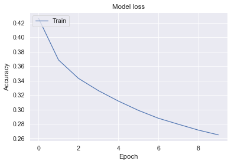

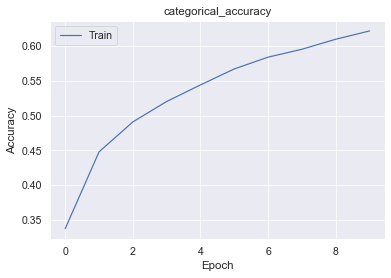

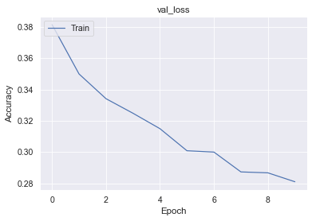

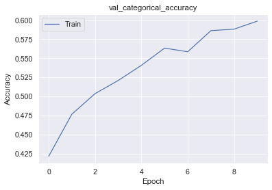

```python
import matplotlib.pyplot as plt


# Plot training & validation accuracy values
fig=plt.figure()
plt.plot(hist.history['loss'])
# plt.plot(hist.history['val_acc'])
# fig=plt.figure()
plt.title('Model loss')
plt.ylabel('Accuracy')
plt.xlabel('Epoch')
plt.legend(['Train', 'Test'], loc='upper left')
plt.show()

fig.savefig('CapsuleCifarmodel1.png')


fig=plt.figure()
plt.plot(hist.history['categorical_accuracy'])
# plt.plot(hist.history['val_acc'])

plt.title('categorical_accuracy')
plt.ylabel('Accuracy')
plt.xlabel('Epoch')
plt.legend(['Train', 'Test'], loc='upper left')
plt.show()
fig.savefig('CapsuleCifarmodel2.png')

fig=plt.figure()
plt.plot(hist.history['val_loss'])
# plt.plot(hist.history['val_acc'])

plt.title('val_loss')
plt.ylabel('Accuracy')
plt.xlabel('Epoch')
plt.legend(['Train', 'Test'], loc='upper left')
plt.show()
fig.savefig('CapsuleCifarmodel3.png')

fig=plt.figure()
plt.plot(hist.history['val_categorical_accuracy'])
# plt.plot(hist.history['val_acc'])

plt.title('val_categorical_accuracy')
plt.ylabel('Accuracy')
plt.xlabel('Epoch')
plt.legend(['Train', 'Test'], loc='upper left')
plt.show()
fig.savefig('CapsuleCifarmodel4.png')
```

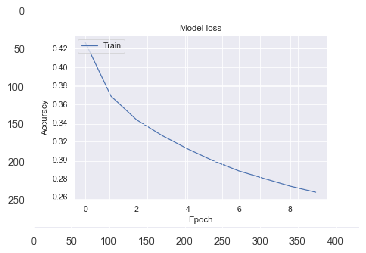

```python
import matplotlib.image as img
im1 =img.imread('CapsuleCifarmodel1.png')
plt.imshow(im1)
```

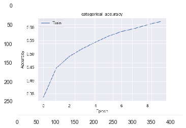

```python
import matplotlib.image as img
im1 =img.imread('CapsuleCifarmodel2.png')
plt.imshow(im1)
```

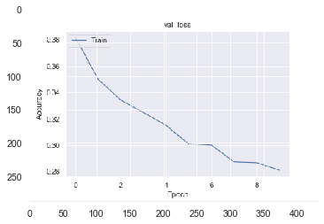

```python
import matplotlib.image as img
im1 =img.imread('CapsuleCifarmodel3.png')
plt.imshow(im1)
```

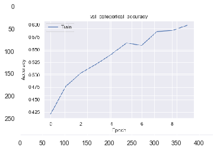

```python
import matplotlib.image as img
im1 =img.imread('CapsuleCifarmodel4.png')
plt.imshow(im1)
```

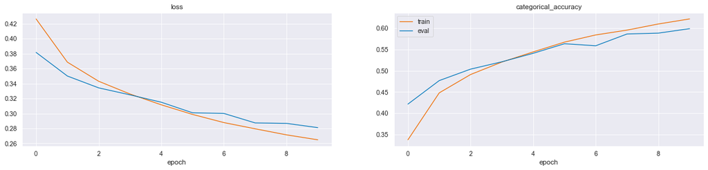

```python
plotHistory(hist.history)
plt.savefig('CapsuleCifarmodel_history.png')
```